# Sales Data Visualization - Version 2

### Outline:

### - Summary of the Annual Sales from 2018 to 2024

1. Annual Sales Data Overview
2. Annual Sales Data by Region
- 2.1 Total Sales by Region

### - Summary of the Quarterly Sales Data by Year

3. Quarterly Sales Data
- 3.1 Quarterly Sales Trend by Year
- 3.2 Quarterly Sales by Region
- 3.3 Quarterly Sales Trend by Region

### - Summary of the Monthly Sales Data by Year

4. Monthly Sales Data by Year
- 4.1 Monthly Sakes Data by Region

### - Summary of Client Distribution

5. Client Sales Trend Over the Years
- 5.1 Most Valuable Client by Total Sales
- 5.2 Customer Retention Rates (2019 to 2023)

```python
import pandas as pd

# Load the dataset
file_path = 'region_cleaned_final_data.csv'
data = pd.read_csv(file_path)

data.head()
```

|  | C1AccountNo | CXRecords | Territory | Latitude | Year | 1 | 2 | 3 | 4 | 5 | ... | q3 | q4 | sales | individual | q1_calculated | q2_calculated | q3_calculated | q4_calculated | individual_calculated | Territory_Group |
| --- | --- | --- | --- | --- | --- | --- | --- | --- | --- | --- | --- | --- | --- | --- | --- | --- | --- | --- | --- | --- | --- |
| 0 | A2061733054*,CNR | 91470CV(.{82 W< | MCOW | 0.000000 | 2018 | 0.00 | 0.00 | 0.00 | 0.0 | 0.00 | ... | 0.00 | 0.00 | 0.00 | 0 | 0.00 | 0.00 | 0.00 | 0.00 | 0.00 | Special |
| 1 | A2061733056$=L._ | 91470FS$KD_> W< | Western | 37.773032 | 2018 | 0.00 | 0.00 | 0.00 | 0.0 | 0.00 | ... | 639.00 | 1438.00 | 4154.00 | 0 | 0.00 | 0.00 | 639.00 | 1438.00 | 2077.00 | West |
| 2 | A2061733057#*N-2 | 91470GQ%![I! W< | Central | 42.135659 | 2018 | 1730.06 | 10023.32 | 108.18 | 0.0 | 0.00 | ... | 0.00 | 1143.74 | 26010.60 | 0 | 11861.56 | 0.00 | 0.00 | 1143.74 | 13005.30 | Midwest |
| 3 | A2061733058)U90^ | 91470I8%.+ML W< | Western | 33.436405 | 2018 | 0.00 | 0.00 | 0.00 | 0.0 | 306.86 | ... | 0.00 | 277.38 | 1168.48 | 0 | 0.00 | 306.86 | 0.00 | 277.38 | 584.24 | West |
| 4 | A2061733059#5)>2 | 91470KJ(,V-0 W< | Central | 0.000000 | 2018 | 0.00 | 0.00 | 0.00 | 0.0 | 0.00 | ... | 153.46 | 0.00 | 306.92 | 0 | 0.00 | 0.00 | 153.46 | 0.00 | 153.46 | Midwest |

5 rows × 29 columns

### Visualization: Summary of the Annual Sales from 2018 to 2024

```python
# Summary statistics by year for total sales
summary_by_year = data.groupby('Year')['individual_calculated'].describe().reset_index()

# Sum of sales for each year
sum_sales_per_year = data.groupby('Year')['individual_calculated'].sum().reset_index(name='sum')

# Merging the sum data with the summary statistics by year
summary_with_sum = pd.merge(summary_by_year, sum_sales_per_year, on='Year')

summary_with_sum
```

|  | Year | count | mean | std | min | 25% | 50% | 75% | max | sum |
| --- | --- | --- | --- | --- | --- | --- | --- | --- | --- | --- |
| 0 | 2018 | 5700.0 | 3484.553367 | 11309.633111 | -97.66 | 235.1200 | 746.640 | 2539.9800 | 332846.49 | 19861954.19 |
| 1 | 2019 | 6201.0 | 4965.038189 | 18788.660287 | -151.83 | 250.8600 | 835.200 | 2825.1000 | 363525.01 | 30788201.81 |
| 2 | 2020 | 5573.0 | 5166.654226 | 17607.290774 | -1226.71 | 256.7500 | 887.200 | 3018.4400 | 335166.15 | 28793764.00 |
| 3 | 2021 | 5898.0 | 5895.078427 | 21567.304097 | -3026.65 | 285.7550 | 958.695 | 3428.9700 | 487406.06 | 34769172.56 |
| 4 | 2022 | 6450.0 | 7247.054132 | 31342.659907 | -7395.10 | 324.6275 | 1055.705 | 3696.0375 | 581180.93 | 46743499.15 |
| 5 | 2023 | 7236.0 | 6800.741042 | 24032.556499 | -566.98 | 331.9950 | 1166.005 | 4198.3900 | 536744.16 | 49210162.18 |
| 6 | 2024 | 4983.0 | 5186.145854 | 17839.985782 | -1556.88 | 289.5300 | 970.610 | 3403.0450 | 349946.52 | 25842564.79 |

### Summary of the Annual Sales Data by Year

### 1. Annual Sales Data Overview

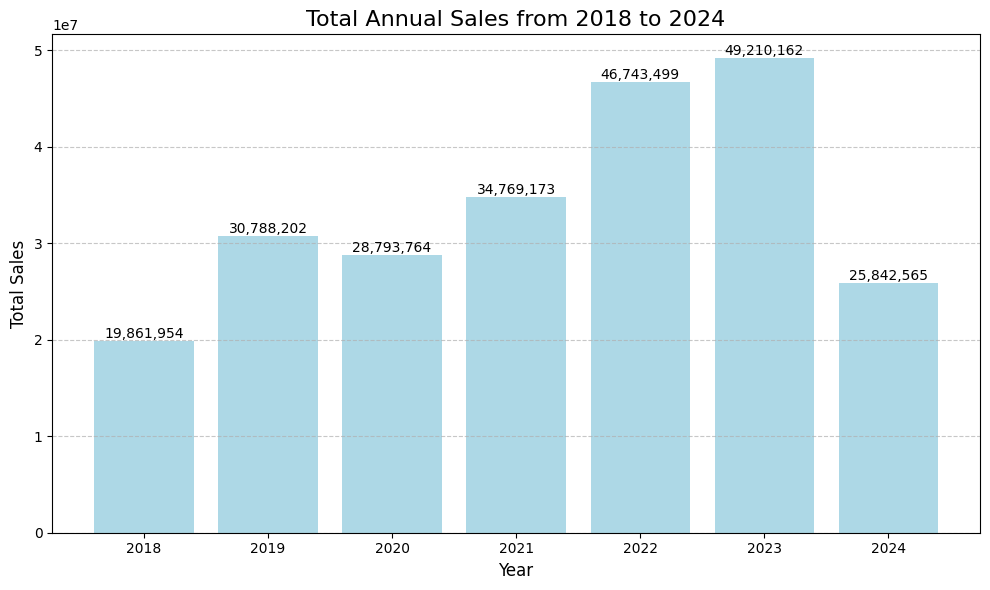

```python
import matplotlib.pyplot as plt

# Creating a visualization for the summary with total sales by year, marking the sum of each year

plt.figure(figsize=(10, 6))

# Plotting total sales per year as a bar chart
bars = plt.bar(summary_with_sum['Year'], summary_with_sum['sum'], color='lightblue')

# Adding labels and title
plt.title('Total Annual Sales from 2018 to 2024', fontsize=16)
plt.xlabel('Year', fontsize=12)
plt.ylabel('Total Sales', fontsize=12)
plt.grid(axis='y', linestyle='--', alpha=0.7)

# Annotating each bar with the sum value
for bar in bars:
    yval = bar.get_height()
    plt.text(bar.get_x() + bar.get_width()/2, yval, f'{yval:,.0f}',
             ha='center', va='bottom', fontsize=10)

plt.tight_layout()
plt.show()
```

### 2. Annual Sales Data by Region

```python
import numpy as np
```

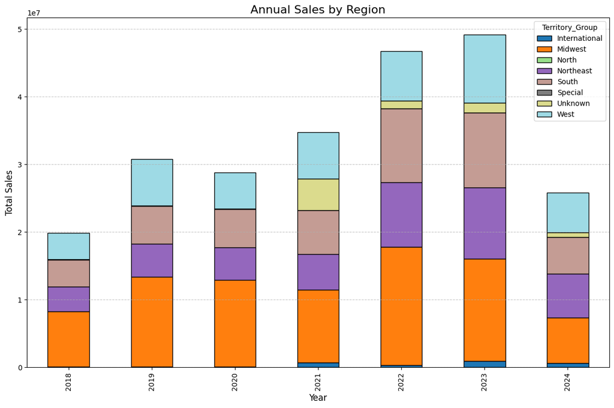

```python
# Grouping the data by Year and Territory_Group to sum up the individual_calculated sales
annual_sales_by_region = data.groupby(['Year', 'Territory_Group'])['individual_calculated'].sum().unstack()

# Plotting the stacked bar chart
plt.figure(figsize=(12, 8))

# Stacked bar chart with regions contributing to the total sales for each year
annual_sales_by_region.plot(kind='bar', stacked=True, figsize=(12, 8), colormap='tab20', edgecolor='black')

# Adding labels and title
plt.title('Annual Sales by Region', fontsize=16)
plt.xlabel('Year', fontsize=12)
plt.ylabel('Total Sales', fontsize=12)
plt.grid(axis='y', linestyle='--', alpha=0.7)

plt.tight_layout()
plt.show()
```

The visualization highlights how different regions have varying sales contributions, allowing for a quick comparison of regional performance across time. The colors in the chart make it easier to observe changes in sales trends by region, such as which areas are consistently strong and how regional sales fluctuate year-over-year. This provides useful insights into geographic sales dynamics.

### 2.1 Total Sales by Region

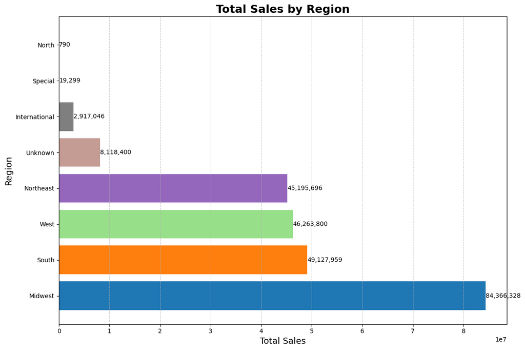

```python
sales_by_region = data.groupby('Territory_Group')['individual_calculated'].sum().reset_index()

sales_by_region = sales_by_region.sort_values(by='individual_calculated', ascending=False)

plt.figure(figsize=(12, 8))

colors = plt.cm.tab20(np.linspace(0, 1, len(sales_by_region)))
plt.barh(sales_by_region['Territory_Group'], sales_by_region['individual_calculated'], color=colors)

for index, value in enumerate(sales_by_region['individual_calculated']):
    plt.text(value, index, f'{value:,.0f}', va='center', fontsize=10)


plt.title('Total Sales by Region', fontsize=18, fontweight='bold')
plt.xlabel('Total Sales', fontsize=14)
plt.ylabel('Region', fontsize=14)

plt.grid(axis='x', linestyle='--', alpha=0.7)

plt.tight_layout()

plt.show()
```

The horizontal bar chart visualizes total sales by region. Each bar represents a region, sorted by total sales, with the actual sales values displayed next to each bar for easy reference. The grid lines enhance readability, making it easier to compare sales figures across regions. This chart provides a quick and clear view of how sales are distributed geographically, helping to identify the top-performing regions at a glance.

### Summary of Quarterly Sales Data

```python
quarterly_sales_by_year = data.groupby('Year')[['q1_calculated', 'q2_calculated', 'q3_calculated', 'q4_calculated']].sum().reset_index()

quarterly_sales_by_year
```

|  | Year | q1_calculated | q2_calculated | q3_calculated | q4_calculated |
| --- | --- | --- | --- | --- | --- |
| 0 | 2018 | 6704159.65 | 5326012.04 | 3529662.04 | 4302120.46 |
| 1 | 2019 | 10976311.94 | 8018689.15 | 6072121.98 | 5721078.74 |
| 2 | 2020 | 12260064.42 | 4745627.57 | 5421627.62 | 6366444.39 |
| 3 | 2021 | 10113958.31 | 8773925.90 | 8142645.96 | 7738642.39 |
| 4 | 2022 | 16744706.66 | 13271448.15 | 8445925.56 | 8281418.78 |
| 5 | 2023 | 20736501.85 | 14851407.92 | 6550832.34 | 7071420.07 |
| 6 | 2024 | 14539948.65 | 9410738.42 | 1891877.72 | 0.00 |

### Visualization: Quarterly Sales Data by Year

### 3. Quarterly Sales Data

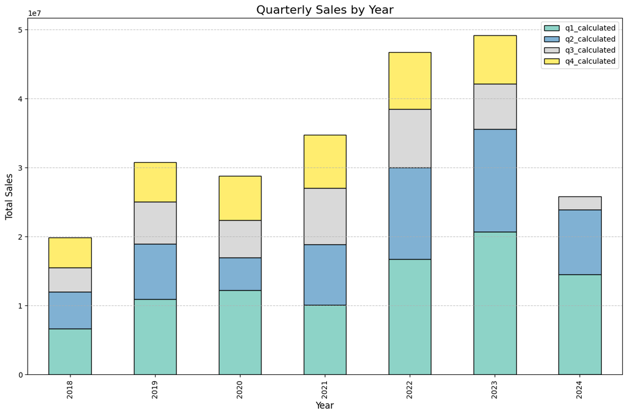

```python
plt.figure(figsize=(12, 8))


quarterly_sales_by_year.set_index('Year')[['q1_calculated', 'q2_calculated', 'q3_calculated', 'q4_calculated']].plot(
    kind='bar', stacked=True, figsize=(12, 8), colormap='Set3', edgecolor='black')

plt.title('Quarterly Sales by Year', fontsize=16)
plt.xlabel('Year', fontsize=12)
plt.ylabel('Total Sales', fontsize=12)

plt.grid(axis='y', linestyle='--', alpha=0.7)

plt.tight_layout()
plt.show()
```

The bar chart visualizes **quarterly sales by year** using a stacked bar format, where each bar represents a year, and the sections of the bar show the sales for each quarter (Q1, Q2, Q3, and Q4). This allows for a clear comparison of quarterly contributions to annual sales, highlighting how different quarters contribute to the overall yearly performance.

### 3.1 Quarterly Sales Data Trend by Year

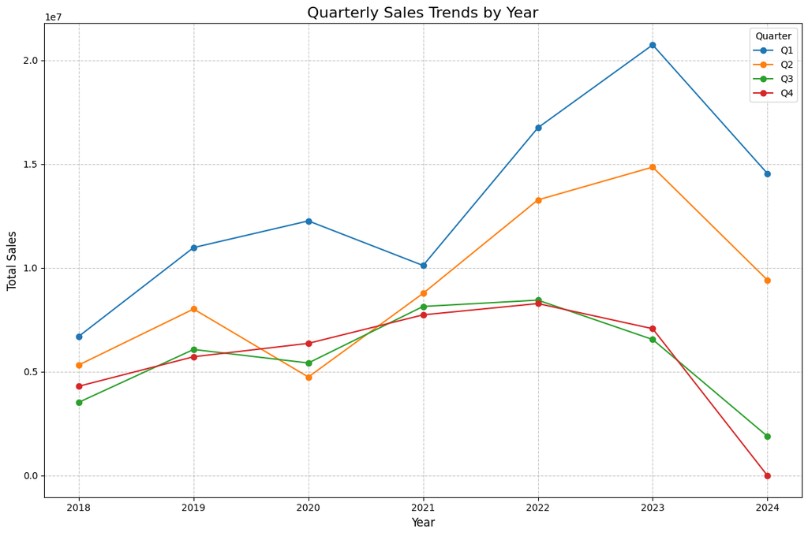

```python
plt.figure(figsize=(12, 8))

plt.plot(quarterly_sales_by_year['Year'], quarterly_sales_by_year['q1_calculated'], label='Q1', marker='o')
plt.plot(quarterly_sales_by_year['Year'], quarterly_sales_by_year['q2_calculated'], label='Q2', marker='o')
plt.plot(quarterly_sales_by_year['Year'], quarterly_sales_by_year['q3_calculated'], label='Q3', marker='o')
plt.plot(quarterly_sales_by_year['Year'], quarterly_sales_by_year['q4_calculated'], label='Q4', marker='o')


plt.title('Quarterly Sales Trends by Year', fontsize=16)
plt.xlabel('Year', fontsize=12)
plt.ylabel('Total Sales', fontsize=12)


plt.legend(title='Quarter')


plt.grid(True, linestyle='--', alpha=0.7)

plt.tight_layout()
plt.show()
```

The line chart illustrates the **quarterly sales trends by year**, highlighting the fluctuations in sales for each quarter from 2018 to 2024. Notably, Q1 consistently shows higher sales compared to other quarters, with a peak in 2023. Q2 also follows a similar trend with a steady increase in recent years. However, Q3 and Q4 exhibit more variability, with Q4 dropping to zero in 2024. Overall, the graph highlights seasonal patterns, with Q1 generally being the strongest quarter for sales across multiple years.

### 3.2 Quarterly Sales by Region

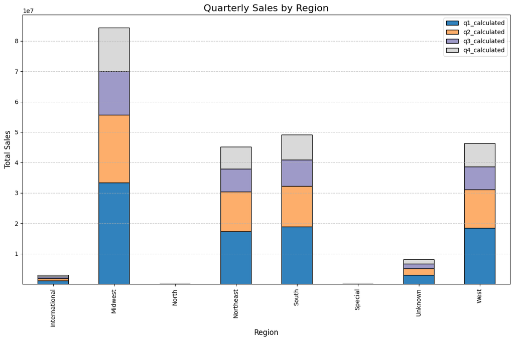

```python
quarterly_sales_by_region = data.groupby(['Territory_Group'])[['q1_calculated', 'q2_calculated', 'q3_calculated', 'q4_calculated']].sum().reset_index()

plt.figure(figsize=(12, 8))

quarterly_sales_by_region.set_index('Territory_Group')[['q1_calculated', 'q2_calculated', 'q3_calculated', 'q4_calculated']].plot(
    kind='bar', stacked=True, figsize=(12, 8), colormap='tab20c', edgecolor='black')

plt.title('Quarterly Sales by Region', fontsize=16)
plt.xlabel('Region', fontsize=12)
plt.ylabel('Total Sales', fontsize=12)

plt.grid(axis='y', linestyle='--', alpha=0.7)

plt.tight_layout()
plt.show()
```

### 3.3 Quarterly Sales Trend by Region

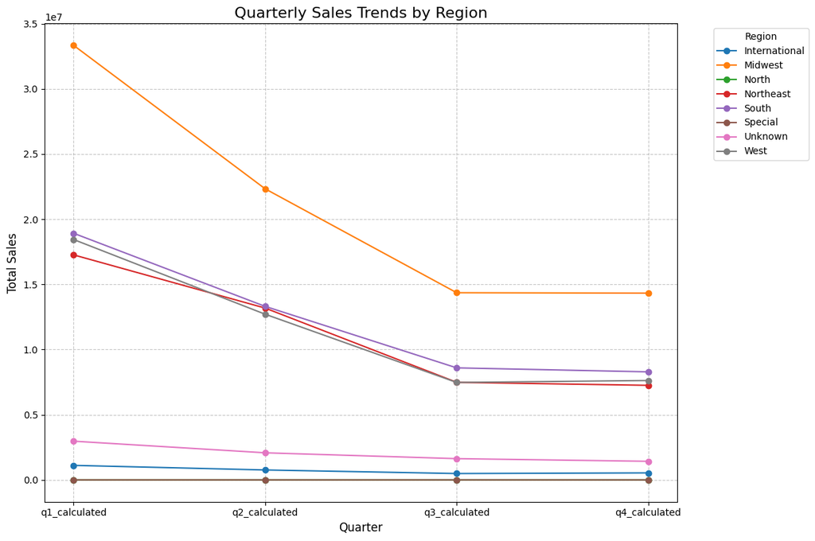

```python
quarterly_sales_trends_by_region = quarterly_sales_by_region.set_index('Territory_Group')[['q1_calculated', 'q2_calculated', 'q3_calculated', 'q4_calculated']].T

plt.figure(figsize=(12, 8))

for region in quarterly_sales_trends_by_region.columns:
    plt.plot(quarterly_sales_trends_by_region.index, quarterly_sales_trends_by_region[region], label=region, marker='o')

plt.title('Quarterly Sales Trends by Region', fontsize=16)
plt.xlabel('Quarter', fontsize=12)
plt.ylabel('Total Sales', fontsize=12)

plt.legend(title='Region', bbox_to_anchor=(1.05, 1), loc='upper left')

plt.grid(True, linestyle='--', alpha=0.7)

plt.tight_layout()
plt.show()
```

### Summary of Monthly Sales Data by Year

```python
# Aggregating monthly sales data by year
monthly_columns = ['1', '2', '3', '4', '5', '6', '7', '8', '9', '10', '11', '12']
monthly_sales_by_year = data.groupby('Year')[monthly_columns].sum().reset_index()

monthly_sales_by_year
```

|  | Year | 1 | 2 | 3 | 4 | 5 | 6 | 7 | 8 | 9 | 10 | 11 | 12 |
| --- | --- | --- | --- | --- | --- | --- | --- | --- | --- | --- | --- | --- | --- |
| 0 | 2018 | 1954990.15 | 2411204.30 | 2337965.20 | 2214113.41 | 1803756.85 | 1308141.78 | 1143314.63 | 1287739.47 | 1098607.94 | 1557901.00 | 1390377.51 | 1353841.95 |
| 1 | 2019 | 3020817.60 | 3913993.34 | 4041501.00 | 2761062.40 | 3176981.00 | 2080645.75 | 2057782.94 | 1975628.87 | 2038710.17 | 2292351.75 | 1807305.37 | 1621421.62 |
| 2 | 2020 | 3832156.52 | 4759742.96 | 3668164.94 | 53832.03 | 2800716.94 | 1891078.60 | 1876532.53 | 1505747.76 | 2039347.33 | 2066716.91 | 1904589.63 | 2395137.85 |
| 3 | 2021 | 2293196.34 | 3473475.66 | 4347286.31 | 3595487.21 | 2388592.61 | 2789846.08 | 2308557.32 | 3077869.08 | 2756219.56 | 2877781.92 | 2713242.86 | 2147617.61 |
| 4 | 2022 | 4083453.40 | 5560197.13 | 7101056.13 | 4944461.58 | 4777452.21 | 3549534.36 | 3260813.14 | 2673293.35 | 2511819.07 | 2668688.82 | 2852857.21 | 2759872.75 |
| 5 | 2023 | 6903014.44 | 6102224.26 | 7731263.15 | 6721609.33 | 4853652.17 | 3276146.42 | 1832487.12 | 2375591.67 | 2342753.55 | 2628327.31 | 2549099.50 | 1893993.26 |
| 6 | 2024 | 5406181.09 | 4353946.64 | 4779820.92 | 3885111.88 | 3336840.75 | 2188785.79 | 1525847.76 | 366029.96 | 0.00 | 0.00 | 0.00 | 0.00 |

### Visualization: Monthly Sales Data by Year

### 4. Monthly Sales Data by Year

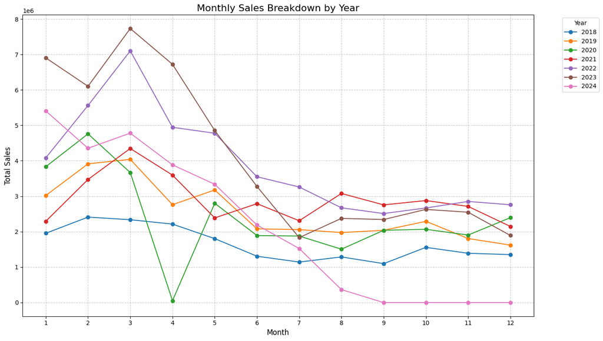

```python
plt.figure(figsize=(14, 8))

for year in monthly_sales_by_year['Year']:
    plt.plot(monthly_columns, monthly_sales_by_year[monthly_sales_by_year['Year'] == year].iloc[:, 1:].values.flatten(), label=str(year), marker='o')


plt.title('Monthly Sales Breakdown by Year', fontsize=16)
plt.xlabel('Month', fontsize=12)
plt.ylabel('Total Sales', fontsize=12)

plt.legend(title='Year', bbox_to_anchor=(1.05, 1), loc='upper left')

plt.grid(True, linestyle='--', alpha=0.7)

plt.tight_layout()
plt.show()
```

### 4.1 Monthly Sales Data by Region

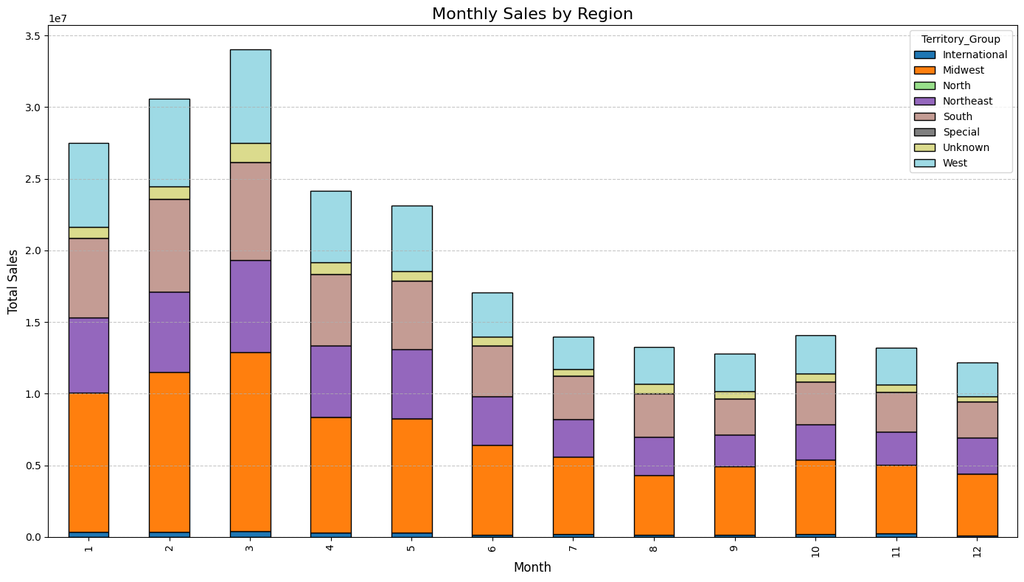

```python
monthly_sales_by_region = data.groupby('Territory_Group')[monthly_columns].sum().reset_index()

plt.figure(figsize=(14, 8))

monthly_sales_by_region.set_index('Territory_Group')[monthly_columns].T.plot(kind='bar', stacked=True, figsize=(14, 8), colormap='tab20', edgecolor='black')

plt.title('Monthly Sales by Region', fontsize=16)
plt.xlabel('Month', fontsize=12)
plt.ylabel('Total Sales', fontsize=12)

plt.grid(axis='y', linestyle='--', alpha=0.7)

plt.tight_layout()
plt.show()
```

### Summary of Client Distribution

```python
# Number of unique clients
unique_clients = data['C1AccountNo'].nunique()

clients_per_region = data.groupby('Territory_Group')['C1AccountNo'].nunique().reset_index()

unique_clients, clients_per_region
```

```
(28395,
   Territory_Group  C1AccountNo
 0   International          619
 1         Midwest         9080
 2           North            1
 3       Northeast         5700
 4           South         6318
 5         Special           11
 6         Unknown          901
 7            West         5765)
```

### 5. Client Sales Trend Over the Years

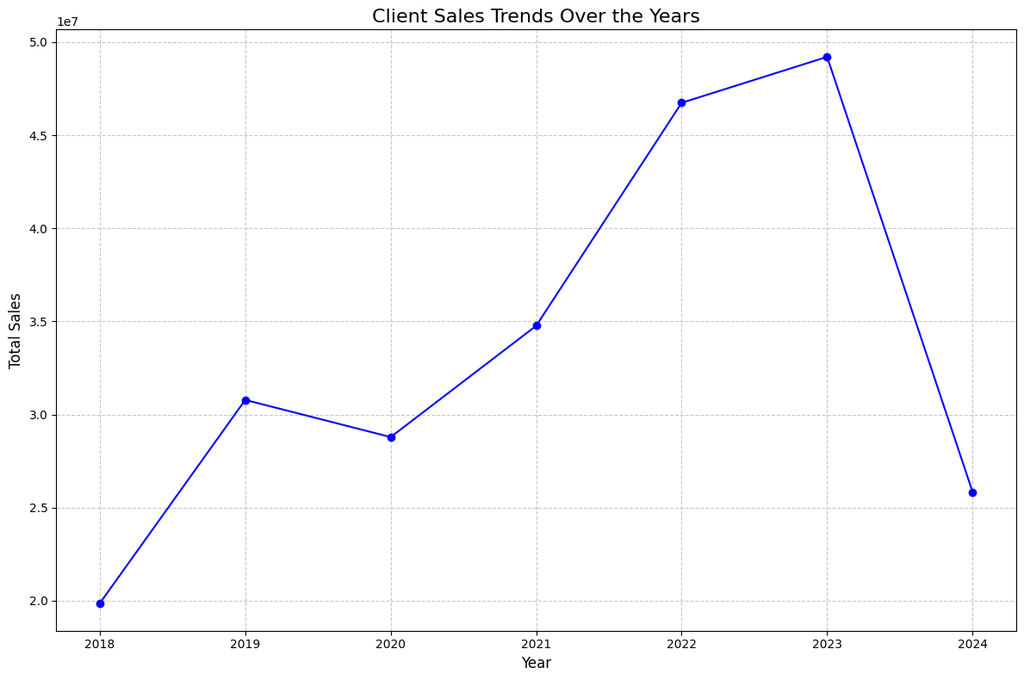

```python
client_sales_trends = data.groupby(['Year'])['individual_calculated'].sum().reset_index()

plt.figure(figsize=(12, 8))

plt.plot(client_sales_trends['Year'], client_sales_trends['individual_calculated'], marker='o', color='b')

plt.title('Client Sales Trends Over the Years', fontsize=16)
plt.xlabel('Year', fontsize=12)
plt.ylabel('Total Sales', fontsize=12)

plt.grid(True, linestyle='--', alpha=0.7)

plt.tight_layout()
plt.show()
```

### 5.1 Most Valuable Client by Total Sales

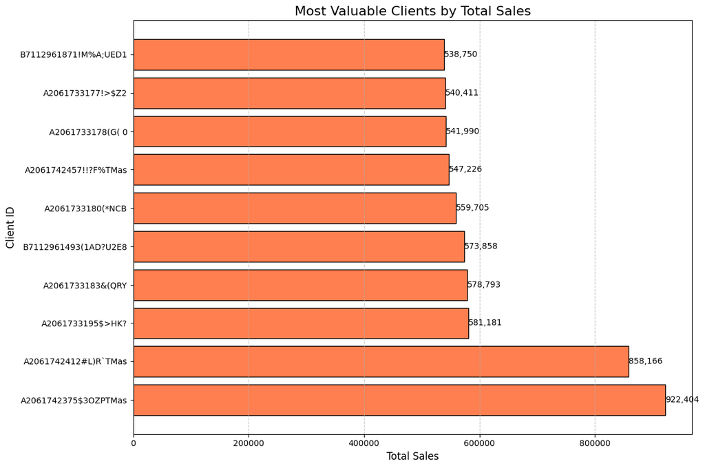

```python
most_valuable_clients = data.groupby('C1AccountNo')['individual_calculated'].sum().reset_index()

most_valuable_clients = most_valuable_clients.sort_values(by='individual_calculated', ascending=False).head(10)

plt.figure(figsize=(12, 8))

bars = plt.barh(most_valuable_clients['C1AccountNo'], most_valuable_clients['individual_calculated'],
                color='coral', edgecolor='black')

plt.title('Most Valuable Clients by Total Sales', fontsize=16)
plt.xlabel('Total Sales', fontsize=12)
plt.ylabel('Client ID', fontsize=12)

plt.grid(axis='x', linestyle='--', alpha=0.7)

for bar in bars:
    plt.text(bar.get_width(), bar.get_y() + bar.get_height()/2,
             f'{bar.get_width():,.0f}', va='center', fontsize=10, color='black')

plt.tight_layout()
plt.show()
```

### 5.2 Customer Retention Rates (2019 to 2023)

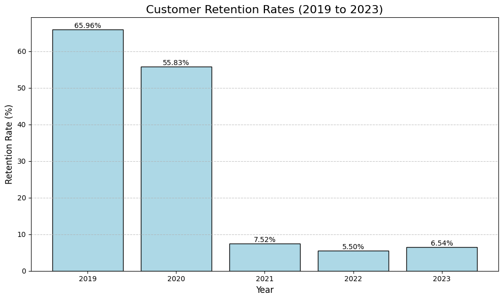

```python
retention_rates = []

for year in range(2019, 2024):
    current_customers = data[data['Year'] == year]['C1AccountNo'].nunique()
    previous_customers = data[data['Year'] == year - 1]['C1AccountNo'].nunique()

    new_customers = data[(data['Year'] == year) & (~data['C1AccountNo'].isin(data[data['Year'] == year - 1]['C1AccountNo']))]['C1AccountNo'].nunique()

    if previous_customers > 0:
        retention_rate = ((current_customers - new_customers) / previous_customers) * 100
    else:
        retention_rate = None

    retention_rates.append({'Year': year, 'Retention Rate (%)': retention_rate})

retention_rates_df = pd.DataFrame(retention_rates)

filtered_retention_rates_df = retention_rates_df[retention_rates_df['Year'].between(2019, 2023)]

plt.figure(figsize=(10, 6))

bars = plt.bar(filtered_retention_rates_df['Year'], filtered_retention_rates_df['Retention Rate (%)'], color='lightblue', edgecolor='black')

plt.title('Customer Retention Rates (2019 to 2023)', fontsize=16)
plt.xlabel('Year', fontsize=12)
plt.ylabel('Retention Rate (%)', fontsize=12)

plt.grid(axis='y', linestyle='--', alpha=0.7)

for bar in bars:
    yval = bar.get_height()
    plt.text(bar.get_x() + bar.get_width()/2, yval, f'{yval:.2f}%',
             ha='center', va='bottom', fontsize=10)

plt.tight_layout()
plt.show()
```